# Fibonacci

## 1 Fibonacci Sequence

Modified from [Fibonacci](https://jaketae.github.io/study/complex-fibonacci/)

Leonardo of Pisa, called Fibonacci (1170–1250), an Italian mathematician, who introduced the Indian position number system that he learned from Arabian scholars to Europe was already mentioned in the first chapter. Despite of his major relevance for the advance of mathematics in Europe and the world he is nowadays more known for an over-simplified illustrating example from biology, concerning the growth of rabbit population. The scheme shown in the following figure leads to the so called Fibonnaci sequence: 1, 1, 2, 3, 5, 8, …

[figure not shown]

The rabbits reproduce after two of the shown time-steps. The figure shows the growth of the population in steps of let's say one month: one initial pair of rabbits thus leads to 5 pairs after 4 generations.

**Task 1**: If there are 1 additional generation per month how many pairs of rabbits will be present after 35 months? Solve the problem using a for-loop!

```python
# Fibonacci numbers
n1 = 1; n2 = 1;
for i in range (1,34):
    n3 = n1+n2
    n1 = n2
    n2 = n3

print (n2)
```

```
9227465
```

Formally the rule for the Fibonacci sequence looks like this:

$$ F_n=F_{n−1}+F_{n−2} $$

There are some different conventions as to where the sequence starts. I personally prefer the one that starts from zero, with zero indexing. Here is what I mean:

$$ F_0=0, F_1=1, F_2=1, F_3=2,⋯$$

Implementing Fibonacci numbers in code is one of the most common exercises that are used to teach concepts such as recursion, memoization, and dynamic programming. The following command sequence shows, how the sequence can be obtained by a function that calls itself.

```python
def bad_fibonacci(n):
    if n < 0:
        raise ValueError(
            "`n` can only be a non-negative integer."
        )
    if n < 2:
        return n
    return bad_fibonacci(n - 1) + bad_fibonacci(n - 2)

bad_fibonacci(35)
```

```
9227465
```

The code above is the standard fibonacci function as we know it, implemented with simple bare bone recursion. While the code works perfectly fine, there is a fatal problem with this code: it recalculates so many values. Namely, in calling bad_fibonacci(n - 1), the program goes all the way up to the (n−1)th fibonacci number. Then, in the next call of bad_fibonacci(n - 2), the program recalculates the same values calculated earlier, up until the (n−2)$^{th}$ Fibonacci number, just one short of the previous one.

**Memoization**

The classic way to deal with this problem is to use a technique known as memoization. The idea is simple: we keep some sort of memo or cache of values that have already been calculated and store them in some data structure that we don’t have to recalculate values that have already been computed prior. Here is a simple implementation.

```python
cache = {0: 0, 1: 1}

def fibonacci(n):
    if n < 0:
        raise ValueError(
            "`n` can only be a non-negative integer."
        )
    if n in cache:
        return cache[n]
    res = fibonacci(n - 1) + fibonacci(n - 2)
    cache[n] = res
    return res

fibonacci(35)
```

```
9227465
```

To see how effective memoization is compared to vanilla recursion, let’s use the timeit module.

```python
%timeit bad_fibonacci(35)
```

```
1.05 s ± 2.4 ms per loop (mean ± std. dev. of 7 runs, 1 loop each)
```

Comparing this to the timeit test on fibonacci() with memoization, the benefits of caching becomes immediately clear:

```python
%timeit fibonacci(35)
```

```
39.6 ns ± 0.0822 ns per loop (mean ± std. dev. of 7 runs, 10,000,000 loops each)
```

1 second and 40 nanoseconds are different by orders of magnitude, and we only asked the functions to calculate the 35$^{th}$ Fibonacci number. We can get a sense of how quickly this disparity would grow if we try to calculate something like the 1000th fibonacci number in the sequence.

Another perk of using caching as above is that we can now get the full sequence up to the 35th fibonacci number.

```python
cache
```

```
{0: 0,
 1: 1,
 2: 1,
 3: 2,
 4: 3,
 5: 5,
 6: 8,
 7: 13,
 8: 21,
 9: 34,
 10: 55,
 11: 89,
 12: 144,
 13: 233,
 14: 377,
```

[output cut: 21 more lines]

The Fibonacci numbers can be nicely arranged as adjacent squares. Combining the edges one obtains the Fibonacci spiral. The Fibonacci spiral has been found in nature, for example in sea shells, here the nautilus.

[figure not shown]

**Mathematics of Binet’s Formula**

Although memoization is interesting, it is not the main topic of today’s post. Instead, I want to discuss Binet’s formula, a formula with which we can calculate the n$^{th}$ Fibonacci number. Binet’s formula states that

$$ F_n = \frac{\left(\frac{1+\sqrt{5}}{2} \right)^n - \left(\frac{1-\sqrt{5}}{2} \right)^n}{\sqrt{5}} $$

We can trivially verify that $F_0=0$ and that $F_1=1$. For more robust empirical verification, we will resort to code later.It is worth noting that the quantity in the parenthesis, namely

$$ ϕ=\frac{1+\sqrt{5}}{2}≈1.61803398875 $$

is otherwise referred to as the Golden ratio. Also observe that the other quantity is the negative inverse of the Golden ratio.

$$ \frac{1-\sqrt{5}}{2}=\frac{-2}{1+\sqrt{5}}≈-1/ϕ $$

**Binet’s Formula in Code**

```python
def binet(n):
    golden = (1 + 5**.5) / 2
    return (golden**n - (- 1 / golden)**n) / 5**.5
```

Intuitively, Binet’s formula has to do with the well-known fact that the ratio between two consecutive Fibonacci numbers approaches the Golden ratio as n goes to infinity.

```python
for i in range (2,35):
    print (binet(i)/binet(i-1))
```

```
1.0
2.0
1.5000000000000002
1.6666666666666667
1.6
1.6249999999999998
1.6153846153846154
1.619047619047619
1.6176470588235294
1.6181818181818184
1.6179775280898878
1.6180555555555554
1.6180257510729616
1.6180371352785148
1.6180327868852458
1.618034447821682
1.6180338134001255
1.618034055727554
1.6180339631667067
1.6180339985218033
1.618033985017358
1.6180339901755973
1.6180339882053252
1.618033988957902
1.6180339886704431
1.6180339887802428
1.618033988738303
1.6180339887543225
1.6180339887482038
1.6180339887505406
1.6180339887496484
1.618033988749989
1.618033988749859
```

An interesting point to note about Binet’s formula is that $n$ doesn’t necessarily have to be a non-negative integer as we had previously assumed. In fact, it can be any number: rational, irrational, real, or even complex. The fact that the Fibonacci numbers can extend to real number indexing becomes more apparent once we code out the formula.

Nothing special at all, this is just a literal transcription of the formula presented above. But now, watch what happens when we try to get the 1.1$^{th}$ fibonacci number, for instance:

```python
binet(1.1)
```

```
(1.009794706934108+0.08139747961593857j)
```

We get a complex Fibonacci number! I thought this was so fascinating, almost like seeing a magic of some sort. Although I had known about the Fibonacci sequence for as long as I can remember, I had never thought about it in continuous terms: in my mind, the Fibonacci sequence was, after all, a sequence — a discrete set of numbers adhering to the simple rule that the next number in line is the sum of the previous two.

The intriguing part is that, even in this complex Fibonacci madness, the simple rule still holds. For instance,

```python
diff = binet(3.1) - (binet(2.1) + binet(1.1))
assert diff.real < 1e-10 and abs(diff.imag) < 1e-10
```

This is because this equality doesn’t hold due to floating point arithmetic. Therefore, we simply verify equivalence by comparing their magnitude with an arbitrarily small number, 1e-10. The takeaway from the code snippet is that $F_n=F_{n−1}+F_{n−2}$ holds, regardless of whether or not n is a non-negative integer. Indeed, Binet’s formula gives us what we might refer to as the interpolation of the fibonacci sequence, in this case extended along the real number line.

**Plotting the Fibonacci Sequence**

A corollary of the real number interpolation of the fibonacci sequence via Binet’s formula is that now we can effectively plot the complex fibonacci numbers on the Cartesian plane. Because n can be continuous, we would expect some graph to appear, where the x-axis represents real numbers, and y, the imaginary.

This requires a bit of a hack though; note that the result of Binet’s formula is a complex number, or a two-dimensional data point. The input to the function is just a one-dimensional real number. Therefore, we need a way of representing a map from a one-dimensional real number line to a two-dimensional complex plane. This is sort of tricky if you think about it: the normal two-dimensional plane as we know it can only represent a mapping from the x-axis to the y-axis—in other words, a transformation from one-dimensional space to another one-dimensional space. A three-dimensional xyz-coordinate system, on the other hand, represents a transformation from a two-dimensional space, represented by x and y, to another one-dimensional space, namely z. We aren’t used to going to other way around, where a one-dimensional space is mapped to a two-dimensional space, as is the case here.

A simple hack that nonetheless makes a lot of sense in this case is to use the real-number line for two purposes: representing the input dimension, namely the real number line, and one component of the output dimension—the real number portion of the output to Binet’s formula. This admittedly results in a loss of information, since finding the point where n=k won’t give us the kth fibonacci number; instead, it will only tell us what the fibonacci number is whose real number component equals k. Nonetheless, this is an approach that makes sense since the real number line is a common dimension in both the input and output data. With this in mind, let’s go ahead and try to plot the interpolation of the fibonacci sequence on the complex plane.

First, we import the modules we will need.

```python
import numpy as np
import matplotlib.pyplot as plt
```

Then, we simply specify the domain on the real number line and generate the fibonacci numbers, separating out the real and imaginary components. Note that x is not going to be used for plotting; instead, we use y_real as the x-axis, and this is where the loss of temporal information comes in, as mentioned earlier.

```python
x = np.linspace(-10, 10, 200).astype(complex)
y_real = []
y_imag = []
for num in x:
    res = binet(num)
    y_real.append(res.real)
    y_imag.append(res.imag)
```

Now, let’s go ahead and plot it out!

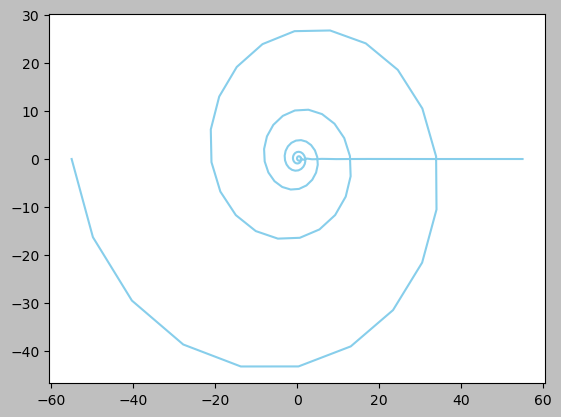

```python
plt.plot(y_real, y_imag, color="skyblue");
```

And there it is, the full fibonacci sequence, interpolated across the real numbers. When I first saw this pattern in Matt Parker’s video, I was simply in awe, a loss of words. There’s something inexplicably beautiful and wonderful at this pattern, almost as if it was some part of God’s plan. Okay, maybe I’m being too melodramatic about a graph, but there is no denying that this pattern is geometrically interesting and pleasing to the eye. Everything looks so intentional and deliberate.

The comments on the aesthetics of the snail shell aside, one point that deserves our attention is what appears to be a straight line. Well, turns out that this is, in fact, not a straight line. The only reason why it appears straight is that the snail pattern overshadows the little vibrations on this portion of the graph. Indeed, zooming in, we see that there is an interesting damping motion going on. This is what the fibonacci sequence would have looked like had we plotted only the positive domain of the real number line.

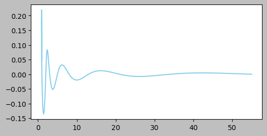

```python
plt.figure(figsize=(6,3))
plt.plot(y_real[110:], y_imag[110:], color="skyblue");
```

A more detailed look on the positive axis reveals a little bow:

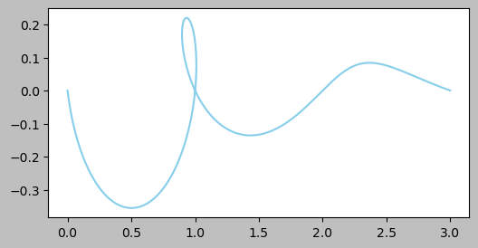

```python
plt.figure(figsize=(6,3))
x = np.linspace(0j,4, 200).astype(complex)
y_real = []
y_imag = []
for num in x:
    res = binet(num)
    y_real.append(res.real)
    y_imag.append(res.imag)

plt.plot(y_real, y_imag, color="skyblue");
```

Let's look at the graph, if we use complex arguments. Here we choose a parallel to the real axis in distance 1.

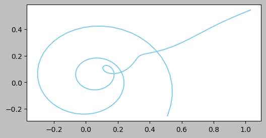

```python
plt.figure(figsize=(6,3))
x = np.linspace(-7+1j,2+1j,200).astype(complex)
y_real = []
y_imag = []
for num in x:
    res = binet(num)
    y_real.append(res.real)
    y_imag.append(res.imag)

plt.plot(y_real, y_imag, color="skyblue");
```

After quitting the spiral the function leaves the area in an angle. Does the angle change with the distance of the parallel from the real axis?

Finally we use the a square of the complex plane as input parameters. As for potential flow the real part of the result of Binet's formula is plotted as filled contours, the imaginary part as contour lines.

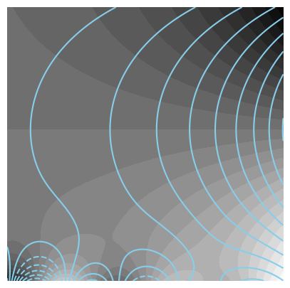

```python
plt.figure(figsize=(5,5))
plt.style.use('grayscale')
n = 1001
x = np.linspace(-4.0,1.0,n); y = np.linspace(0.5,5.5,n)

# Construct complex mesh
X, Y = np.meshgrid(x,y); Z = X + Y*1j

B = np.zeros((n,n)).astype(complex)
for i in range(len(B)):
    for j in range(len(B[i])):
        B[i,j] = binet(Z[i,j])

plt.contourf(X,Y,np.real(B),25)
plt.contour(X,Y,np.imag(B),15,colors='skyblue')
plt.axis("off");
```

This looks like a holomorphic function: the contour-lines of real and imaginary parts meet at right angles! Is it really holomorphic?

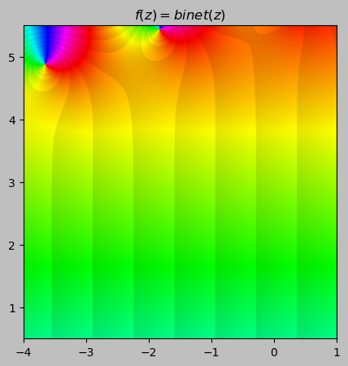

```python
from matplotlib.colors import hsv_to_rgb
n = 1001
x = np.linspace(-4.0,1.0,n); y = np.linspace(0.5,5.5,n)
X, Y = np.meshgrid(x, y); Z = X + 1j*Y
golden = (1 + 5**.5) / 2
F = (golden**Z - (-1/golden)**Z) / 5**.5

fig, ax = plt.subplots(figsize=(5, 5))
s = 0.9
A = np.log(np.abs(F)) * 10 / (np.pi); A = A - A//1
amin = np.min(A); amax = np.max(A)
H = (np.angle(-F) + np.pi) / (2*np.pi)
V = (A-amin) / (amax-amin) * (1-s) + s
img = hsv_to_rgb(np.dstack((H, np.ones(F.shape), V)))
ax.imshow(img, extent=[min(x), max(x), min(y), max(y)])
ax.set_title('$f(z) = binet(z)$')
plt.show()
```

**Lucas Numbers**

Connected to the Fibonacci Numbers are the Lucas Numbers. They have the same recursion formula. Only the starting values are different. The Lucas numbers start with 2 and 1.

[figure not shown]

In correspondence with the above memoisation code we can obain a limited sequence as follows.

```python
cache = {0: 2, 1: 1}

def lucas(n):
    if n < 0:
        raise ValueError(
            "`n` can only be a non-negative integer."
        )
    if n in cache:
        return cache[n]
    res = lucas(n - 1) + lucas(n - 2)
    cache[n] = res
    return res

lucas(35)
cache
```

```
{0: 2,
 1: 1,
 2: 3,
 3: 4,
 4: 7,
 5: 11,
 6: 18,
 7: 29,
 8: 47,
 9: 76,
 10: 123,
 11: 199,
 12: 322,
 13: 521,
 14: 843,
```

[output cut: 21 more lines]

In analogy to the Binet formula an expicite formula can be derived:

$$ F_n = {(\frac{1+\sqrt{5}}{2})}^n + {(\frac{1-\sqrt{5}}{2})}^n $$

Let's write a function for it!

```python
def lucas(n):
    golden = (1 + 5**.5) / 2
    return (golden**n + (- 1 / golden)**n)
```

and check the development of the series with input of a complex numbers

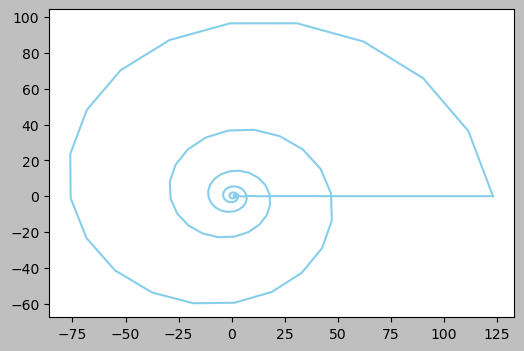

```python
plt.figure(figsize=(6,4))
x = np.linspace(-10, 10, 200).astype(complex)
y_real = []
y_imag = []
for n in x:
    res = lucas(n)
    y_real.append(res.real)
    y_imag.append(res.imag)

plt.plot(y_real, y_imag, color="skyblue");
```

What seems to be a straight ray from the origin to the right, is the result of input values on the positive real axis. Restriction the input to these values, one obtains again a graph that is fluctuating along the horizontal axis.

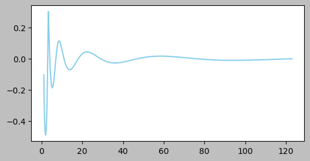

```python
plt.figure(figsize=(6,3))
plt.plot(y_real[110:], y_imag[110:], color="skyblue");
```

Extending the exploration to the complex plane, reults to a figure that is almost identical to the one obtained for the Fibonacci numbers.

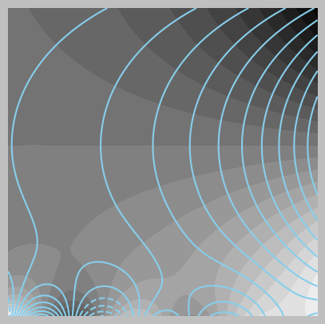

```python
plt.figure(figsize=(5,5))
plt.style.use('grayscale')
n = 1001
x = np.linspace(-4.0,1.0,n); y = np.linspace(0.5,5.5,n)

# Construct complex mesh
X, Y = np.meshgrid(x,y); Z = X + Y*1j

B = np.zeros((n,n)).astype(complex)
for i in range(len(B)):
    for j in range(len(B[i])):
        B[i,j] = lucas(Z[i,j])

plt.contourf(X,Y,np.real(B),25)
plt.contour(X,Y,np.imag(B),15,colors='skyblue')
plt.axis("off");
```